# An introduction to the SpatialFeatures Class

Guan Gui

School of Mathematics and Statistics, The University of Sydney, Sydney, NSW, 2006, Australia  
Charles Perkins Centre, The University of Sydney, Sydney, NSW, 2006, Australia  
Sydney Precision Data Science Centre, The University of Sydney, Sydney, NSW, 2006, Australia

20 May 2024

# 1 Installation

The R package `SpatialFeatures` contains functions to extract features from molecule-resolved spatial transcriptomics data using objects from the `MoleculeExperiment` class.

## 1.1 Installation

You can install the latest release of `SpatialFeatures` from GitHub using the devtools package:

```r
if (!require("devtools", quietly = TRUE)) {
  install.packages("devtools")
}
devtools::install_github("SydneyBioX/SpatialFeatures")
```

# 2 Demonstrating Major Functions and Visualizing SpatialFeatures

## 2.1 Load Required Libraries

```r
library(ggplot2)
library(devtools)
library(SpatialFeatures)
library(MoleculeExperiment)
library(SummarizedExperiment)
library(dplyr)
```

## 2.2 Create Example Dataset

Load an example `MoleculeExperiment` object with Xenium data:

```r
repoDir <- system.file("extdata", package = "MoleculeExperiment")
repoDir <- paste0(repoDir, "/xenium_V1_FF_Mouse_Brain")

me <- readXenium(repoDir, keepCols = "essential")
me
```

```
#> MoleculeExperiment class
#>
#> molecules slot (1): detected
#> - detected:
#> samples (2): sample1 sample2
#> -- sample1:
#> ---- features (137): 2010300C02Rik Acsbg1 ... Zfp536 Zfpm2
#> ---- molecules (962)
#> ---- location range: [4900,4919.98] x [6400.02,6420]
#> -- sample2:
#> ---- features (143): 2010300C02Rik Acsbg1 ... Zfp536 Zfpm2
#> ---- molecules (777)
#> ---- location range: [4900.01,4919.98] x [6400.16,6419.97]
#>
#>
#> boundaries slot (1): cell
#> - cell:
#> samples (2): sample1 sample2
#> -- sample1:
#> ---- segments (5): 67500 67512 67515 67521 67527
#> -- sample2:
#> ---- segments (9): 65043 65044 ... 65070 65071
```

## 2.3 Generate `SpatialFeature` Data Based on Different Segmentation Methods

This function `GenerateFeatureData(me)` processes the given data (`me`) and returns feature data based on multiple assay types, including: - Sub-Sector - Sub-Concentric - Super-Sector - Super-Concentric

```r
feature_data_list <- SpatialFeatures::GenerateFeatureData(me)
lapply(feature_data_list, head, n = 4)
```

```
#> $sub_sector
#>   x_section y_section segment_id sample_id  area_id
#> 1   4894.30  6417.712      65043   sample2 65043_01
#> 2   4895.15  6413.888      65043   sample2 65043_01
#> 3   4896.46  6420.652      65043   sample2 65043_01
#> 4   4894.30  6417.712      65043   sample2 65043_01
#>
#> $sub_concentric
#> # A tibble: 4 × 5
#> # Groups:   segment_id [1]
#>   x_section y_section segment_id sample_id area_id
#>       <dbl>     <dbl> <chr>      <chr>     <chr>
#> 1     4898.     6413. 67500      sample1   67500_01
#> 2     4897.     6413. 67500      sample1   67500_01
#> 3     4896.     6414. 67500      sample1   67500_01
#> 4     4895.     6416. 67500      sample1   67500_01
#>
#> $super_sector
#>   x_section y_section segment_id sample_id  area_id
#> 1   4896.85  6413.462      65043   sample2 65043_01
#> 2   4895.15  6413.888      65043   sample2 65043_01
#> 3   4893.84  6407.123      65043   sample2 65043_01
#> 4   4897.24  6406.273      65043   sample2 65043_01
#>
#> $super_concentric
#> # A tibble: 4 × 5
#> # Groups:   segment_id [1]
#>   x_section y_section segment_id sample_id area_id
#>       <dbl>     <dbl> <chr>      <chr>     <chr>
#> 1     4905.     6400. 67500      sample1   67500_01
#> 2     4899.     6401. 67500      sample1   67500_01
#> 3     4894.     6408. 67500      sample1   67500_01
#> 4     4890.     6418. 67500      sample1   67500_01
```

## 2.4 Load boundaries to `MoleculeExperiment` object

This function `loadBoundariesToMEforAll(me)` divides the image data into equal areas and processes each area internally to extract the respective boundary features, updating the `MoleculeExperiment` object with these new features.

```r
boundaries_me_list <- SpatialFeatures::loadBoundariesToMEforAll(me)
me_4 = boundaries_me_list[[4]]
me_4
```

```
#> MoleculeExperiment class
#>
#> molecules slot (1): detected
#> - detected:
#> samples (1): sample2
#> -- sample2:
#> ---- features (143): 2010300C02Rik Acsbg1 ... Zfp536 Zfpm2
#> ---- molecules (777)
#> ---- location range: [4900.01,4919.98] x [6400.16,6419.97]
#>
#>
#> boundaries slot (5): cell sub_sector sub_concentric super_sector
#>   super_concentric
#> - cell:
#> samples (1): sample2
#> -- sample2:
#> ---- segments (2): 65064 65070
#> - sub_sector:
#> samples (1): sample2
#> -- sample2:
#> ---- segments (24): 65064_01 65064_02 ... 65070_11 65070_12
#> - sub_concentric:
#> samples (1): sample2
#> -- sample2:
#> ---- segments (12): 65064_01 65064_02 ... 65070_05 65070_06
#> - super_sector:
#> samples (1): sample2
#> -- sample2:
#> ---- segments (22): 65064_01 65064_02 ... 65070_10 65070_11
#> - super_concentric:
#> samples (1): sample2
#> -- sample2:
#> ---- segments (14): 65064_01 65064_02 ... 65070_06 65070_07
```

## 2.5 Draw the Feature Boundary Plots

Visualize the spatial molecule and cell boundary map with SpatialFeature boundaries.

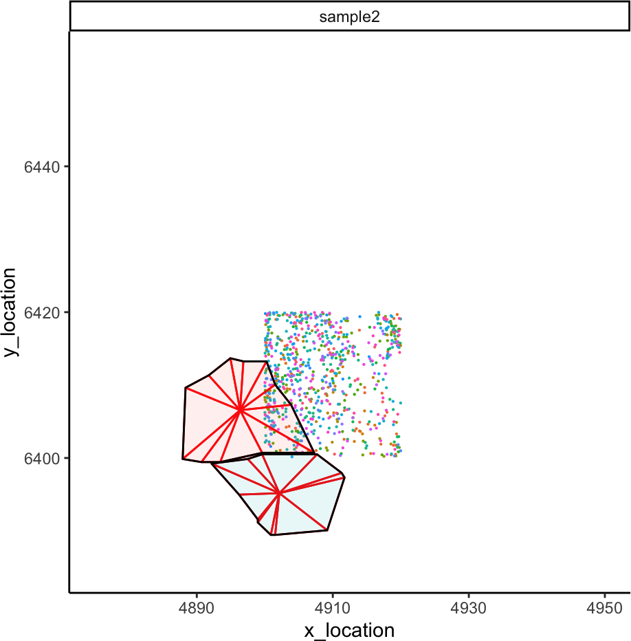

```r
ggplot_me() +
  # add molecule points and colour by feature name
  geom_point_me(me_4, byColour = "feature_id", size = 0.1) +
  # add nuclei segments and colour the border with red
  geom_polygon_me(me_4, assayName = "sub_sector", fill = NA, colour = "red") +
  # add cell segments and colour by cell id
  geom_polygon_me(me_4, byFill = "segment_id", colour = "black", alpha = 0.1) +
  # zoom in to selected patch area
  coord_cartesian(xlim = c(4875, 4950), ylim = c(6385, 6455))
```

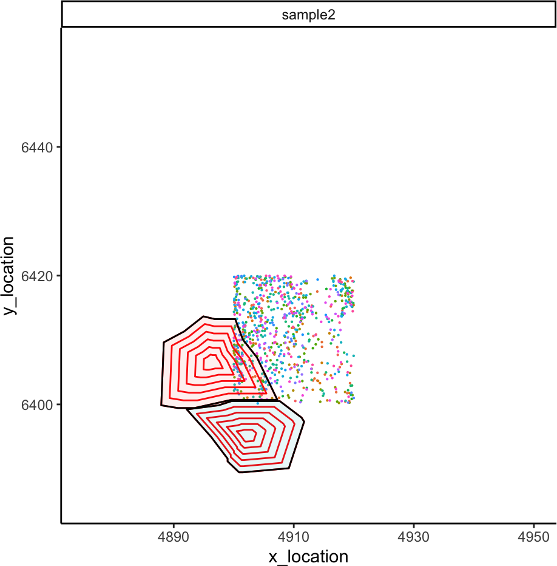

```r
ggplot_me() +
  # add molecule points and colour by feature name
  geom_point_me(me_4, byColour = "feature_id", size = 0.1) +
  # add nuclei segments and colour the border with red
  geom_polygon_me(me_4, assayName = "sub_concentric", fill = NA, colour = "red") +
  # add cell segments and colour by cell id
  geom_polygon_me(me_4, byFill = "segment_id", colour = "black", alpha = 0.1) +
  # zoom in to selected patch area
  coord_cartesian(xlim = c(4875, 4950), ylim = c(6385, 6455))
```

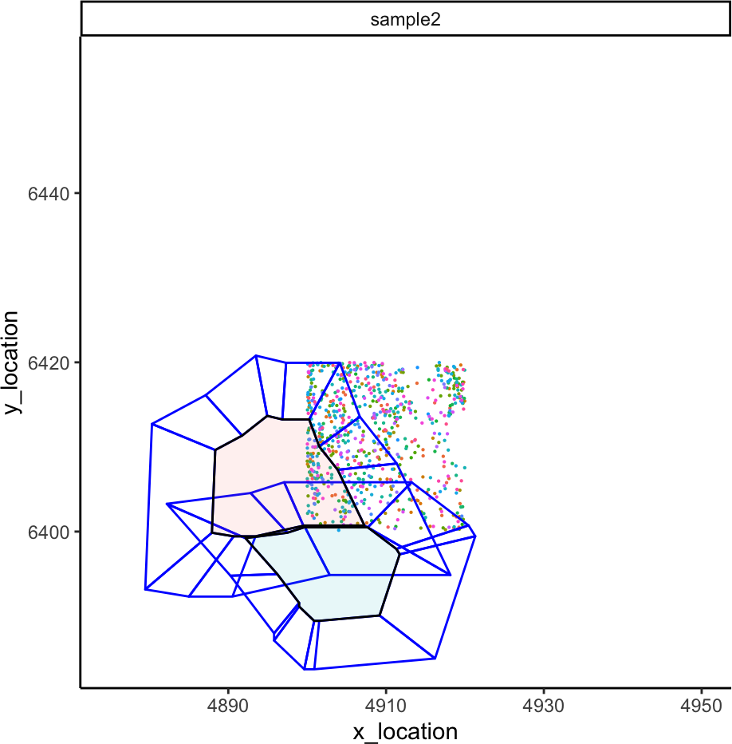

```r
ggplot_me() +
  # add molecule points and colour by feature name
  geom_point_me(me_4, byColour = "feature_id", size = 0.1) +
  # add nuclei segments and colour the border with red
  geom_polygon_me(me_4, assayName = "super_sector", fill = NA, colour = "blue") +
  # add cell segments and colour by cell id
  geom_polygon_me(me_4, byFill = "segment_id", colour = "black", alpha = 0.1) +
  # zoom in to selected patch area
  coord_cartesian(xlim = c(4875, 4950), ylim = c(6385, 6455))
```

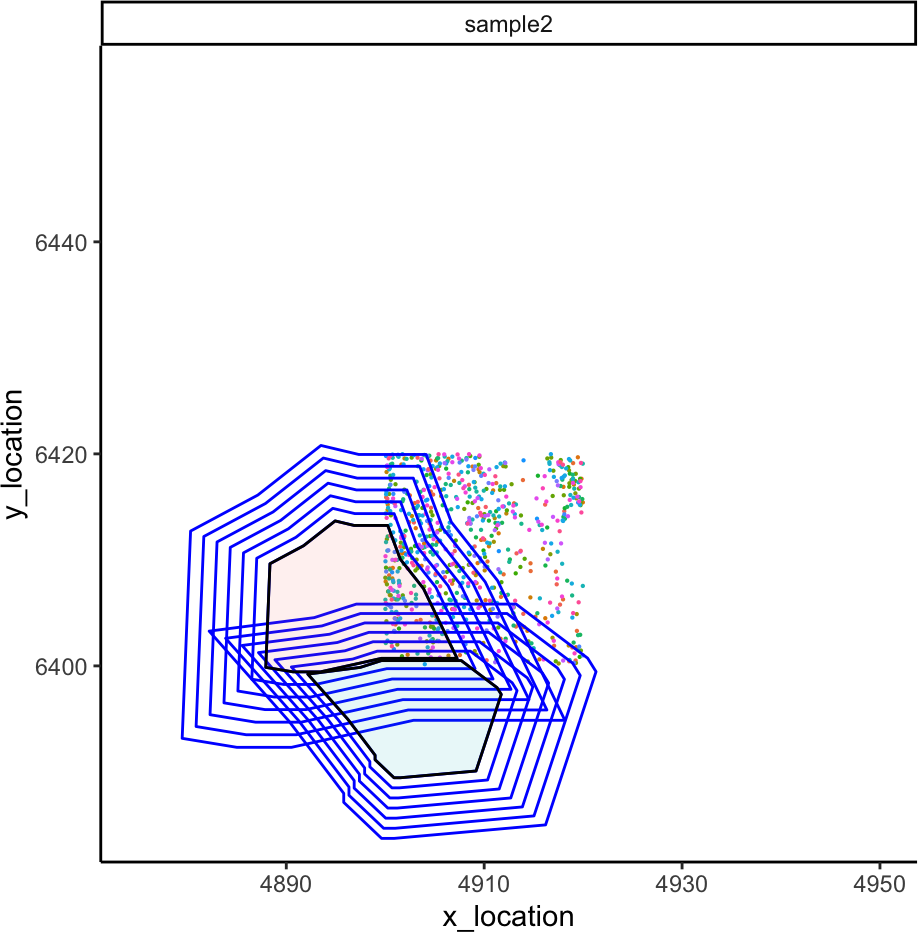

```r
ggplot_me() +
  # add molecule points and colour by feature name
  geom_point_me(me_4, byColour = "feature_id", size = 0.1) +
  # add nuclei segments and colour the border with red
  geom_polygon_me(me_4, assayName = "super_concentric", fill = NA, colour = "blue") +
  # add cell segments and colour by cell id
  geom_polygon_me(me_4, byFill = "segment_id", colour = "black", alpha = 0.1) +
  # zoom in to selected patch area
  coord_cartesian(xlim = c(4875, 4950), ylim = c(6385, 6455))
```

## 2.6 Create Entropy Matrix

This function `EntropyMatrix()` computes the entropy of a counts matrix from a `MoleculeExperiment` object based on the given assay type.

```r
em_list_4 = SpatialFeatures::EntropyMatrix(me_4, c("sub_sector", "sub_concentric", "super_sector", "super_concentric"), nCores = 1)
lapply(em_list_4, head, n = 4)
```

```
#> $sub_sector
#>               sample2.65064 sample2.65070
#> 2010300C02Rik     0.6931472             0
#> Acsbg1            0.0000000             0
#> Adgrl4            0.0000000             0
#> Aldh1a2           0.0000000             0
#>
#> $sub_concentric
#>               sample2.65064 sample2.65070
#> 2010300C02Rik     0.6931472             0
#> Acsbg1            0.0000000             0
#> Adgrl4            0.0000000             0
#> Aldh1a2           0.0000000             0
#>
#> $super_sector
#>               sample2.65064 sample2.65070
#> 2010300C02Rik             0     0.0000000
#> Acsbg1                    0     0.5623351
#> Adgrl4                    0     0.0000000
#> Aldh1a2                   0     0.0000000
#>
#> $super_concentric
#>               sample2.65064 sample2.65070
#> 2010300C02Rik      1.386294     0.6931472
#> Acsbg1             0.000000     0.6931472
#> Adgrl4             0.000000     0.0000000
#> Aldh1a2            0.000000     0.0000000
```

## 2.7 Create `SummarizedExperiment` Object

This function `EntropySummarizedExperiment()` Convert the entropy matrix into a `SummarizedExperiment` object.

```r
se_4 = SpatialFeatures::EntropySummarizedExperiment(em_list_4, me_4)
se_4
```

```
#> class: SummarizedExperiment
#> dim: 715 2
#> metadata(0):
#> assays(1): counts
#> rownames(715): sub_sector_2010300C02Rik sub_sector_Acsbg1 ...
#>   genecount_Zfp536 genecount_Zfpm2
#> rowData names(2): FeatureCategory FeatureGene
#> colnames(2): sample2.65064 sample2.65070
#> colData names(5): Cell Sample_id x_central y_central boundaries
```

# 3 Full Process Tutorial: From `MoleculeExperiment` to `SummarizedExperiment`

This section provides a complete tutorial on transforming an input `MoleculeExperiment` (me) object into a final output `SummarizedExperiment` (se) object.

## 3.1 Read the Original MoleculeExperiment Object

Load the example data from the `MoleculeExperiment` package:

```r
repoDir <- system.file("extdata", package = "MoleculeExperiment")
repoDir <- paste0(repoDir, "/xenium_V1_FF_Mouse_Brain")

me <- readXenium(repoDir, keepCols = "essential")
```

## 3.2 Load `SpatialFeatures` Boundaries

Load the `SpatialFeatures` boundaries into the `MoleculeExperiment` object:

```r
melist <- loadBoundariesToMEforAll(me, k = 5)
```

## 3.3 Compute and Combine the Entropy Matrices

Initialize an Empty List to Store Split `SummarizedExperiment` Objects. Loop through the desired range of r values, compute the entropy matrices, and combine them into a single `SummarizedExperiment` object:

```r
se_list <- list()

for (r in 1:12) {
  if (melist[r] == "null") next

  splitted_me <- melist[[r]]
  em_list <- SpatialFeatures::EntropyMatrix(splitted_me, c("sub_sector", "sub_concentric", "super_sector", "super_concentric"), nCores = 1)
  se_object <- SpatialFeatures::EntropySummarizedExperiment(em_list, splitted_me)
  se_list[[r]] <- se_object
}

se_list <- Filter(Negate(is.null), se_list)
combined_se <- SpatialFeatures::combineSE(se_list)
```

## 3.4 Inspect the Combined SummarizedExperiment Object

Check the structure and content of the combined SummarizedExperiment object:

```r
combined_se
```

```
#> class: SummarizedExperiment
#> dim: 890 14
#> metadata(0):
#> assays(1): counts
#> rownames(890): sub_sector_2010300C02Rik sub_sector_Acsbg1 ...
#>   genecount_Zfp536 genecount_Zfpm2
#> rowData names(2): FeatureCategory FeatureGene
#> colnames(14): sample1.67521 sample1.67527 ... sample2.65067
#>   sample2.65071
#> colData names(5): Cell Sample_id x_central y_central boundaries
```

```r
colData(combined_se)
```

```
#> DataFrame with 14 rows and 5 columns
#>                        Cell   Sample_id x_central y_central
#>                 <character> <character> <numeric> <numeric>
#> sample1.67521 sample1.67500     sample1   4896.19   6415.14
#> sample1.67527 sample2.65043     sample2   4896.46   6420.65
#> sample2.65051 sample2.65044     sample2   4905.03   6421.68
#> sample2.65063 sample1.67512     sample1   4909.74   6411.80
#> sample1.67500 sample2.65055     sample2   4908.54   6409.46
#> ...                     ...         ...       ...       ...
#> sample2.65064 sample2.65051     sample2   4922.77   6429.22
#> sample2.65070 sample2.65063     sample2   4928.03   6415.25
#> sample1.67515 sample1.67515     sample1   4912.42   6402.93
#> sample2.65067 sample2.65067     sample2   4923.71   6406.08
#> sample2.65071 sample2.65071     sample2   4920.63   6398.99
#>                                                    boundaries
#>                                                        <list>
#> sample1.67521 4896.85:6413.46,4895.15:6413.89,4894.30:6417.71
#> sample1.67527 4901.95:6417.07,4901.52:6418.56,4900.89:6419.41
#> sample2.65051 4904.71:6399.65,4898.76:6401.35,4894.30:6407.94
#> sample2.65063 4911.51:6397.95,4907.48:6400.71,4904.07:6407.30
#> sample1.67500 4905.77:6404.11,4906.20:6407.73,4907.05:6412.19
#> ...                                                       ...
#> sample2.65064 4919.59:6408.36,4915.98:6411.34,4915.76:6411.98
#> sample2.65070 4922.35:6404.54,4919.80:6407.94,4920.23:6413.46
#> sample1.67515 4924.90:6402.62,4923.62:6402.84,4922.14:6403.48
#> sample2.65067 4923.84:6394.34,4921.71:6394.76,4917.25:6395.82
#> sample2.65071 4908.96:6395.61,4904.93:6399.44,4905.56:6403.26
```

```r
rowData(combined_se)
```

```
#> DataFrame with 890 rows and 2 columns
#>                          FeatureCategory   FeatureGene
#>                              <character>   <character>
#> sub_sector_2010300C02Rik     Subcellular 2010300C02Rik
#> sub_sector_Acsbg1            Subcellular        Acsbg1
#> sub_sector_Adamts2           Subcellular       Adamts2
#> sub_sector_Adamtsl1          Subcellular      Adamtsl1
#> sub_sector_Adgrl4            Subcellular        Adgrl4
#> ...                                  ...           ...
#> genecount_Vip                  Genecount           Vip
#> genecount_Vwc2l                Genecount         Vwc2l
#> genecount_Wfs1                 Genecount          Wfs1
#> genecount_Zfp536               Genecount        Zfp536
#> genecount_Zfpm2                Genecount         Zfpm2
```